# Project #2

Repetimos el mismo proceso de ajuste de hiperparámetros que antes.

```python
# estimando los parámetros
est_xgb_params = {
    'n_estimators':np.arange(10,1000,10),
    'max_features':['auto','sqrt'],
    'max_depth':np.arange(1,11,1),
    'min_samples_split':[2,5,10],
    'min_samples_leaf':[1,2,4],
    'bootstrap':[True]
}
```

```python
# usar la cuadrícula de parámetros estimados y hacer RandomizedSearchCV antes de ajustar
est_xgb_hyp_model = RandomForestRegressor(random_state = 42)
est_xgb_hyp = RandomizedSearchCV(est_xgb_hyp_model,est_xgb_params,n_iter=10,cv=3,n_jobs=-1)
est_xgb_hyp.fit(X_train, Y_train)
est_xgb_hyp_predictions = est_xgb_hyp.predict(X_test)
est_xgb_hyp_predictions = [int(x) for x in np.round(est_xgb_hyp_predictions,0)];
```

```python
est_xgb_hyp_accuracy_score = accuracy_score(Y_test,est_xgb_hyp_predictions)
est_xgb_hyp_precision_score = precision_score(Y_test,est_xgb_hyp_predictions)
est_xgb_hyp_recall_score = recall_score(Y_test,est_xgb_hyp_predictions)
est_xgb_hyp_f1_score = f1_score(Y_test,est_xgb_hyp_predictions)
est_xgb_hyp_confusion = confusion_matrix(Y_test,est_xgb_hyp_predictions)
final_results_hyp.loc[len(final_results_hyp)] = ["XGBoost - RandomizedSearchCV",est_xgb_hyp_accuracy_score,est_xgb_hyp_precision_score,est_xgb_hyp_recall_score,est_xgb_hyp_f1_score]
```

```python
# Obteniendo los mejores parámetros de RandomizedSearchCV
xgb_hyp_params = est_xgb_hyp.best_params_
print(xgb_hyp_params)
```

```
{'n_estimators': 530, 'min_samples_split': 2, 'min_samples_leaf': 2, 'max_features': 'sqrt', 'max_depth': 8, 'bootstrap': True}
```

```python
# convertir estos parámetros para que se lean
xgb_hyp_param_values = {}
for key, value in xgb_hyp_params.items():
    xgb_hyp_param_values[key] = [value]
print(xgb_hyp_param_values)
```

```
{'n_estimators': [530], 'min_samples_split': [2], 'min_samples_leaf': [2], 'max_features': ['sqrt'], 'max_depth': [8], 'bootstrap': [True]}
```

```python
# usando los mejores parámetros obtenidos y haciendo GridSearchCV antes de ajustar
xgb_hyp_model = RandomForestRegressor(random_state = 42)
xgb_hyp = GridSearchCV(xgb_hyp_model,xgb_hyp_param_values,cv=3,n_jobs=-1)
xgb_hyp.fit(X_train, Y_train)
xgb_hyp_predictions = xgb_hyp.predict(X_test)
xgb_hyp_predictions = [int(x) for x in np.round(xgb_hyp_predictions,0)];
```

```python
xgb_hyp_accuracy_score = accuracy_score(Y_test,xgb_hyp_predictions)
xgb_hyp_precision_score = precision_score(Y_test,xgb_hyp_predictions)
xgb_hyp_recall_score = recall_score(Y_test,xgb_hyp_predictions)
xgb_hyp_f1_score = f1_score(Y_test,xgb_hyp_predictions)
xgb_hyp_confusion = confusion_matrix(Y_test,xgb_hyp_predictions)
final_results_hyp.loc[len(final_results_hyp)] = ["XGBoost - GridSearchCV",xgb_hyp_accuracy_score,xgb_hyp_precision_score,xgb_hyp_recall_score,xgb_hyp_f1_score]
```

### Comparación de resultados (ajuste de hiperparámetros)

```python
# examinando la tabla de datos para esta etapa de análisis
final_results_hyp
```

|  | method | accuracy | precision | recall | f1 |
| --- | --- | --- | --- | --- | --- |
| 0 | Random Forest - RandomizedSearchCV | 0.799148 | 0.631922 | 0.532967 | 0.578241 |
| 1 | Random Forest - GridSearchCV | 0.799148 | 0.631922 | 0.532967 | 0.578241 |
| 2 | XGBoost - RandomizedSearchCV | 0.796309 | 0.625407 | 0.527473 | 0.572280 |
| 3 | XGBoost - GridSearchCV | 0.796309 | 0.625407 | 0.527473 | 0.572280 |

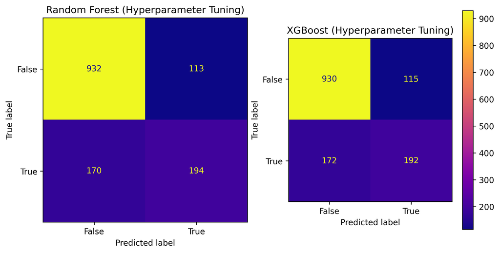

```python
# Comparar matrices de confusión para esta etapa de análisis
fig, ax = plt.subplots(1,2,sharex=False, sharey=False, figsize=(10, 5), dpi=300)
ax[0].set_title('Random Forest (Hyperparameter Tuning)')
ax[1].set_title('XGBoost (Hyperparameter Tuning)')

ConfusionMatrixDisplay(rf_hyp_confusion,display_labels=[False,True]).plot(ax=ax[0],cmap='plasma',colorbar=False)
ConfusionMatrixDisplay(xgb_hyp_confusion,display_labels=[False,True]).plot(ax=ax[1],cmap='plasma',colorbar=True)
fig.show()
```

Encontramos que ambos modelos tienen matrices de confusión similares.

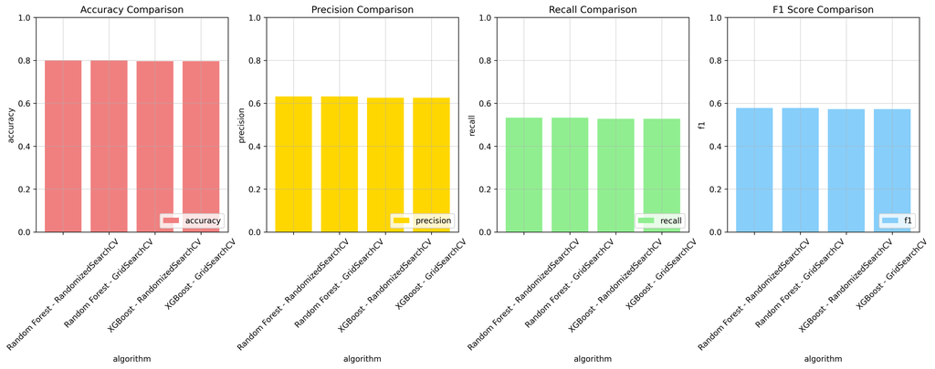

```python
# comparando todas las métricas para esta etapa de análisis
fig, ax = plt.subplots(1, 4, sharex=True, sharey=False, figsize=(20, 5), dpi=300)
x_labels = final_results_hyp['method']
indices = np.arange(len(x_labels))
width = 0.3

# primera fila - SIN hiperparámetros
#row=0, col=0
ax[0].bar(indices,final_results_hyp['accuracy'],color="lightcoral",alpha=1,label="accuracy")
ax[0].grid(True,alpha=0.5)
ax[0].set_ylim(0,1)
ax[0].set_xlabel("algorithm")
ax[0].set_ylabel("accuracy")
ax[0].set_title("Accuracy Comparison")
ax[0].legend(loc='lower right')
ax[0].set_xticks(indices, x_labels, rotation=45)

#row=0, col=1
ax[1].bar(indices,final_results_hyp['precision'],color="gold",alpha=1,label="precision")
ax[1].grid(True,alpha=0.5)
ax[1].set_ylim(0,1)
ax[1].set_xlabel("algorithm")
ax[1].set_ylabel("precision")
ax[1].set_title("Precision Comparison")
ax[1].legend(loc='lower right')
ax[1].set_xticks(indices, x_labels, rotation=45)

#row=0, col=2
ax[2].bar(indices,final_results_hyp['recall'],color="lightgreen",alpha=1,label="recall")
ax[2].grid(True,alpha=0.5)
ax[2].set_ylim(0,1)
ax[2].set_xlabel("algorithm")
ax[2].set_ylabel("recall")
ax[2].set_title("Recall Comparison")
ax[2].legend(loc='lower right')
ax[2].set_xticks(indices, x_labels, rotation=45)

#row=0, col=3
ax[3].bar(indices,final_results_hyp['f1'],color="lightskyblue",alpha=1,label="f1")
ax[3].grid(True,alpha=0.5)
ax[3].set_ylim(0,1)
ax[3].set_xlabel("algorithm")
ax[3].set_ylabel("f1")
ax[3].set_title("F1 Score Comparison")
ax[3].legend(loc='lower right')
ax[3].set_xticks(indices, x_labels, rotation=45)
```

Descubrimos que no hay diferencia en el rendimiento de cada uno de los modelos cuando usamos RandomizedSearchCV primero y luego usamos best_params del resultado y volvemos a ejecutar el modelo con el modelo GridSearchCV.

Ahora compararemos los resultados del ajuste de hiperparámetros con las dos primeras etapas de análisis: no SMOTE y SMOTE.

```python
# preparar df para comparar las tres etapas del análisis
pre_hyp_comparison_no_smote = final_results_no_smote[2:4]
pre_hyp_comparison_smote = final_results_smote[2:4]
post_hyp_comparison = final_results_hyp.iloc[[0,2]]
```

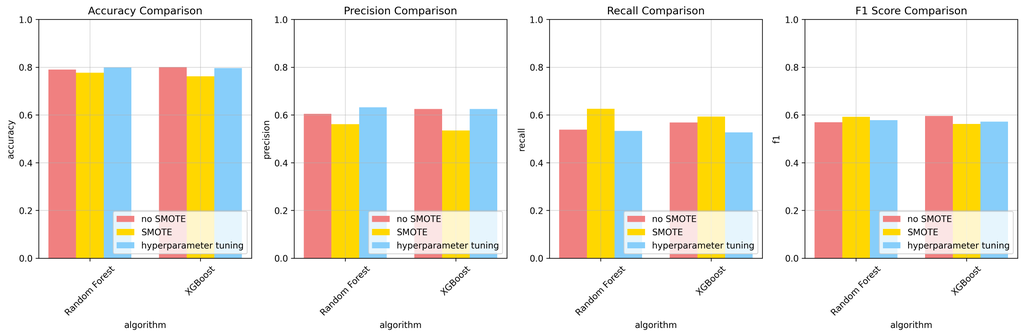

```python
fig, ax = plt.subplots(1, 4, sharex=True, sharey=False, figsize=(20, 5), dpi=300)
x_labels = ['Random Forest','XGBoost']
indices = np.arange(len(x_labels))
width = 0.25

# primera fila - SIN hiperparámetros
#row=0, col=0
ax[0].bar(indices+width,pre_hyp_comparison_no_smote['accuracy'],width,color="lightcoral",alpha=1,label="no SMOTE")
ax[0].bar(indices+2*width,pre_hyp_comparison_smote['accuracy'],width,color="gold",alpha=1,label="SMOTE")
ax[0].bar(indices+3*width,post_hyp_comparison['accuracy'],width,color="lightskyblue",alpha=1,label="hyperparameter tuning")
ax[0].grid(True,alpha=0.5)
ax[0].set_ylim(0,1)
ax[0].set_xlabel("algorithm")
ax[0].set_ylabel("accuracy")
ax[0].set_title("Accuracy Comparison")
ax[0].legend(loc='lower right')
ax[0].set_xticks(indices+2*width, x_labels, rotation=45)

#row=0, col=1
ax[1].bar(indices+width,pre_hyp_comparison_no_smote['precision'],width,color="lightcoral",alpha=1,label="no SMOTE")
ax[1].bar(indices+2*width,pre_hyp_comparison_smote['precision'],width,color="gold",alpha=1,label="SMOTE")
ax[1].bar(indices+3*width,post_hyp_comparison['precision'],width,color="lightskyblue",alpha=1,label="hyperparameter tuning")
ax[1].grid(True,alpha=0.5)
ax[1].set_ylim(0,1)
ax[1].set_xlabel("algorithm")
ax[1].set_ylabel("precision")
ax[1].set_title("Precision Comparison")
ax[1].legend(loc='lower right')
ax[1].set_xticks(indices+2*width, x_labels, rotation=45)

#row=0, col=2
ax[2].bar(indices+width,pre_hyp_comparison_no_smote['recall'],width,color="lightcoral",alpha=1,label="no SMOTE")
ax[2].bar(indices+2*width,pre_hyp_comparison_smote['recall'],width,color="gold",alpha=1,label="SMOTE")
ax[2].bar(indices+3*width,post_hyp_comparison['recall'],width,color="lightskyblue",alpha=1,label="hyperparameter tuning")
ax[2].grid(True,alpha=0.5)
ax[2].set_ylim(0,1)
ax[2].set_xlabel("algorithm")
ax[2].set_ylabel("recall")
ax[2].set_title("Recall Comparison")
ax[2].legend(loc='lower right')
ax[2].set_xticks(indices+2*width, x_labels, rotation=45)

#row=0, col=3
ax[3].bar(indices+width,pre_hyp_comparison_no_smote['f1'],width,color="lightcoral",alpha=1,label="no SMOTE")
ax[3].bar(indices+2*width,pre_hyp_comparison_smote['f1'],width,color="gold",alpha=1,label="SMOTE")
ax[3].bar(indices+3*width,post_hyp_comparison['f1'],width,color="lightskyblue",alpha=1,label="hyperparameter tuning")
ax[3].grid(True,alpha=0.5)
ax[3].set_ylim(0,1)
ax[3].set_xlabel("algorithm")
ax[3].set_ylabel("f1")
ax[3].set_title("F1 Score Comparison")
ax[3].legend(loc='lower right')
ax[3].set_xticks(indices+2*width, x_labels, rotation=45)
```

Al comparar los resultados de las tres etapas del análisis, vemos que en términos de recuperación, el análisis SMOTE proporcionó los mejores resultados para cada uno de los modelos Random Forest y XGBoost, en comparación con los métodos de ajuste de hiperparámetros y no SMOTE.